# Oil in marine protected areas

Which countries and which MPAs are exposed to satellite-detected oil slicks?

2026-09-29

**Setup: packages and data**

```r
library(data.table)
library(ggplot2)
library(scales)
library(reactable)
library(sf)
source("R/plots.R")
use_dark_theme()   # charts and tables match the dark report stylesheet

exposure <- as.data.table(dedupe_sites(readRDS("data/mpa_exposure.rds")))
cls      <- as.data.frame(readRDS("data/class_summary.rds"))
pts      <- as.data.table(readRDS("data/slick_points.rds"))
info     <- readRDS("data/run_info.rds")

fmt  <- function(x, d = 0) format(round(x, d), big.mark = ",", nsmall = d)
pct  <- function(x) sprintf("%.0f%%", 100 * x)

oiled   <- exposure[n_slicks > 0]
by_cls  <- exposure[, .(n = .N, oiled = sum(n_slicks > 0),
                        share = mean(n_slicks > 0)), by = .(prot_class, class_label)][order(prot_class)]
top     <- as.data.table(top_mpas(as.data.frame(exposure)))
a       <- cls[cls$class == "all", ]
```

## The question

In September 2026 SkyTruth published a global estimate of marine oil pollution: around 1.6 million km² of ocean surface covered by oil slicks every year, most of it from ships and offshore platforms, and most of it inside national waters. Their report notes in passing that marine protected areas are not spared.

This note takes that further with the same underlying data, SkyTruth’s [Cerulean](https://cerulean.skytruth.org) slick detections from Sentinel-1 radar, and asks which countries and which protected areas are actually exposed to oil, and how much.

Between January 2023 and December 2025, Cerulean recorded 18,500 slicks matched to a nearby vessel or platform. Of the 16,346 marine protected areas in the WDPA, **654 (4%) had at least one detected inside them.**

## Country by country

Which countries have the most oil inside their protected areas, and is it a few sites or most of them? Each square below is one MPA; countries are ranked by the total oil-slick area detected inside their MPAs.

**Show code: country ranking**

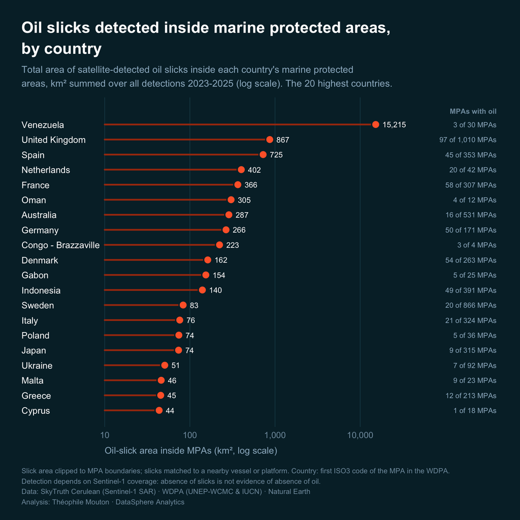

```r
plot_country_ranking(as.data.frame(exposure), info, 20)
```

The squares show how that oil is spread across each country’s network: a few heavily hit sites, or most of its MPAs.

**Show code: country grid**

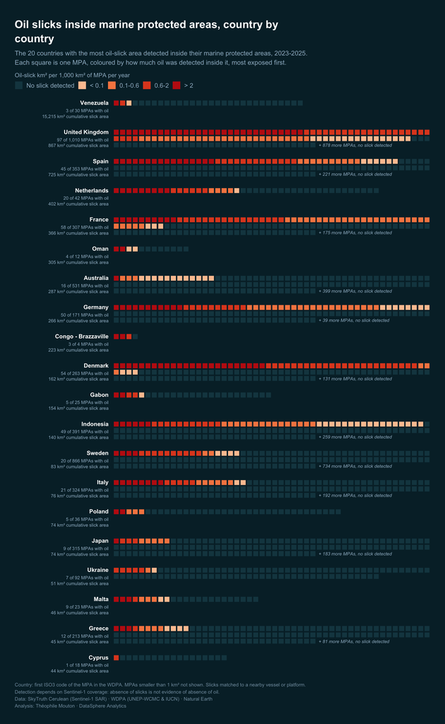

```r
plot_country_grid(as.data.frame(exposure), info, n_countries = 20)
```

## MPA-level exposure

Oil exposure summarised by IUCN protection level, then MPA by MPA. Both tables are sortable (click a column header) and the second one is searchable.

### By protection level

**Show code: protection-level table**

```r
cls_tbl <- data.frame(
  `Protection class` = cls$label,
  MPAs               = cls$n_mpas,
  `With slicks`      = cls$n_mpas_oiled,
  `Share with slicks` = 100 * cls$n_mpas_oiled / cls$n_mpas,
  `Density inside`   = cls$dens_in,
  `Density around`   = cls$dens_ring,
  `Ratio [95% CI]`   = sprintf("%.2f [%.2f-%.2f]", cls$ratio, cls$ratio_lo, cls$ratio_hi),
  check.names = FALSE)

reactable(cls_tbl, theme = table_theme(), compact = TRUE, pagination = FALSE,
          resizable = TRUE,                 # drag a header's right edge to resize
          striped = TRUE, highlight = TRUE,
          columns = list(
            `Protection class`  = colDef(minWidth = 190, style = list(fontWeight = 600)),
            `Share with slicks` = colDef(format = colFormat(suffix = "%", digits = 1)),
            `Density inside`    = colDef(format = colFormat(digits = 3)),
            `Density around`    = colDef(format = colFormat(digits = 3))),
          defaultColDef = colDef(format = colFormat(separators = TRUE)))
```

| Protection class | MPAs | With slicks | Share with slicks | Density inside | Density around | Ratio [95% CI] |
| --- | --- | --- | --- | --- | --- | --- |
| No-take (IUCN I-III) | 3126 | 62 | 1.98336532309661 | 0.219950670483633 | 3.08879689295051 | 0.07 [0.05-0.10] |
| Multiple-use (IUCN IV-VI) | 6959 | 184 | 2.64405805431815 | 2.61918768231813 | 2.87789908349522 | 0.91 [0.73-1.12] |
| Category not reported | 7003 | 523 | 7.46822790232757 | 0.627477281967152 | 4.8544179807255 | 0.13 [0.10-0.16] |
| All MPAs | 17088 | 769 | 4.500234082397 | 1.75806608178708 | 3.31059087121955 | 0.53 [0.44-0.63] |

Densities are km² of oil slick per 10,000 km² of ocean per year. “Around” is the unprotected ocean within 25 km of the MPAs, which shares their satellite coverage and shipping context, so the ratio compares like with like.

### All MPAs with oil

Every MPA with at least one slick detected inside it, ordered by the cumulative oil-slick area inside its boundary (the same measure as the country chart): the area of every slick detected there over 2023-2025, added up. Because the same waters can be oiled many times, this can exceed the MPA’s own area. “Oil per 1,000 km²” divides that by the MPA’s size: it puts small, heavily hit reserves at the top when you sort by it, which is why it is not the default order.

**Show code: MPA table**

```r
ft <- oiled[order(-oil_km2),
            .(MPA = NAME, Country = country, Designation = DESIG_ENG,
              IUCN = IUCN_CAT, `Area (km²)` = marine_km2,
              Slicks = n_slicks, `Months with slicks` = n_months,
              `Cumulative slick area (km²)` = oil_km2,
              `Oil per 1,000 km² per yr` = oil_per_1000km2_yr)]
lvl <- poll_bins(ft$`Oil per 1,000 km² per yr`)
heat <- setNames(POLL_COLS_LIGHT[seq_along(levels(lvl))], levels(lvl))

# Colour key for the shaded column (light table: darker = more oil)
key <- htmltools::div(
  style = "display:flex;flex-wrap:wrap;gap:.35rem 1rem;align-items:center;font-size:.8rem;color:#9cb7c9;margin:.2rem 0 .6rem;",
  htmltools::span(style = "color:#ffffff;font-weight:600;", "Oil per 1,000 km\u00b2 per yr:"),
  lapply(names(heat), function(l) htmltools::span(
    style = "display:inline-flex;align-items:center;gap:.35rem;",
    htmltools::span(style = sprintf(
      "width:.95rem;height:.95rem;border-radius:2px;display:inline-block;background:%s;", heat[[l]])),
    l)),
  htmltools::span(style = "font-style:italic;", "darker = more oil"))

tbl <- reactable(ft, theme = table_theme(), searchable = TRUE, defaultPageSize = 25,
          resizable = TRUE,                 # drag a header's right edge to resize
          compact = TRUE, striped = TRUE, highlight = TRUE,
          height = 640,                     # scroll inside the table: header stays put
          columns = list(
            # MPA and Country stay frozen on the left when scrolling sideways
            MPA         = colDef(minWidth = 220, sticky = "left",
                                 style = list(fontWeight = 600, background = "inherit"),
                                 headerStyle = list(background = "#cfe0e6")),
            Country     = colDef(minWidth = 120, sticky = "left",
                                 style = list(background = "inherit",
                                              borderRight = "1px solid #b7cdd5"),
                                 headerStyle = list(background = "#cfe0e6",
                                                    borderRight = "1px solid #b7cdd5")),
            Designation = colDef(minWidth = 160),
            IUCN        = colDef(minWidth = 115, align = "center"),
            `Area (km²)` = colDef(format = colFormat(separators = TRUE, digits = 0)),
            `Cumulative slick area (km²)` = colDef(format = colFormat(separators = TRUE, digits = 1)),
            `Oil per 1,000 km² per yr` = colDef(
              format = colFormat(digits = 2),
              style = function(value, index) {
                bg <- heat[[as.character(lvl[index])]]
                list(background = bg, fontWeight = 600,
                     color = if (as.integer(lvl[index]) >= 4) "#ffffff" else TABLE_INK)
              })),
          defaultColDef = colDef(format = colFormat(separators = TRUE)))

htmltools::tagList(key, tbl)
```

Oil per 1,000 km² per yr: No slick detected < 0.1 0.1-0.7 0.7-2 > 2 darker = more oil

| MPA | Country | Designation | IUCN | Area (km²) | Slicks | Months with slicks | Cumulative slick area (km²) | Oil per 1,000 km² per yr |
| --- | --- | --- | --- | --- | --- | --- | --- | --- |
| Lago de Maracaibo | Venezuela | Critical Area with Treatment Priority (ACPT) | VI | 12848.2 | 918 | 36 | 15214.1855867928 | 384.048385033036 |
| Marine Musandam Reserve | Oman | Nature Reserve | VI | 5153.67 | 64 | 25 | 292.148638670042 | 18.3851332815125 |
| Corredor de migración de cetáceos del Mediterráneo | Spain | Marine Protected Area | VI | 46613.46 | 87 | 31 | 237.907479466487 | 1.65529833077552 |
| Tasman Fracture | Australia | Australian Marine Park | VI | 19965.015625 | 32 | 12 | 195.856406403019 | 3.18161517448096 |
| Southern North Sea | United Kingdom | Marine Protected Area (OSPAR) | Not Assigned | 36982 | 96 | 32 | 192.458822019561 | 1.68782319538558 |
| Parc National Conkouati-Douli | Congo - Brazzaville | National Park | II | 4725 | 25 | 17 | 187.715384638743 | 12.8847968864002 |
| Wadden Sea | Germany | World Heritage Site (natural or mixed) | Not Applicable | 11574.1306654882 | 54 | 25 | 88.044055733332 | 2.46712515278845 |
| North Norfolk Sandbanks and Saturn Reef | United Kingdom | Marine Protected Area (OSPAR) | Not Reported | 3609.01088436878 | 11 | 8 | 74.48587421063 | 6.6936846684779 |
| Reserve aquatique du Grand Sud du Gabon | Gabon | Aquatic reserve | Not Reported | 27512.2689657445 | 15 | 10 | 70.2005598374964 | 0.827548944248596 |
| Reserve aquatique de Mandji-Etimboue | Gabon | Aquatic reserve | Not Reported | 4055.31112004914 | 37 | 23 | 67.5320677393767 | 5.40089073105011 |

[output cut: 644 more lines]

## Caveats

**Detection is not measurement.** Cerulean detects slicks on Sentinel-1 radar images. A place imaged twice a month will record fewer slicks than one imaged every few days, whatever the true pollution. The per-MPA figures are therefore *detected* exposure, and the open ocean and some high-latitude regions are under-sampled. The class comparison controls for this with neighbouring waters; the per-MPA ranking does not.

**Only source-matched slicks.** Following SkyTruth’s recommendation, slicks are kept only if Cerulean’s attribution model links them to a nearby vessel or offshore platform (collated score > 0). This removes most false positives but also slicks from unknown sources, which biases the sample towards shipping lanes and oil fields.

**Protection class is taken from IUCN management categories as reported to the WDPA.** Categories I-III are treated as no-take, IV-VI as multiple-use. Many MPAs report no category at all, and the category describes management intent, not enforcement.

**Sites listed more than once are counted once.** The WDPA often records the same place under several designations (for example a national marine protected area that is also an Emerald Network or Natura 2000 site). Records with the same country, name and area are merged so their oil is not double-counted.

**Slick area is the surface footprint on the day of the image,** not a volume. A thin sheen and a thick spill of the same extent count the same.

**Attribution is proximity, not proof.** A slick inside an MPA was detected there; it was not necessarily released there, and the nearby vessel is a candidate, not a culprit.

## Reproducing this

```bash
Rscript prep/build_data.R      # downloads + analysis, writes data/ (30-60 min first run)
Rscript linkedin_figures.R     # PNGs in outputs/
quarto render index.qmd
```

Slicks: max_source_collated_score GT 0, 2023-01-01 to 2025-12-31. Grid: 5 km equal-area (Equal Earth). Ring: 25 km. Bootstrap: 2,000 resamples of months. Data built on 2026-09-29.

The chart functions live in `R/plots.R`:

**Show code: R/plots.R**

```r
# Shared plotting helpers: used by index.qmd and linkedin_figures.R
# so the report and the LinkedIn images stay identical.

library(ggplot2)

INK   <- "#0b0b0b"; INK2 <- "#52514e"; MUTED <- "#898781"
GRIDC <- "#e1e0d9"; SURF <- "#fcfcfb"

# Protection classes: two blues (darker = stronger protection) + grey for unknown
CLASS_COLS <- c("1" = "#1c5cab", "2" = "#6da7ec", "3" = "#a8a69f", "all" = "#52514e")

# IUCN management categories: blues for I-III (no-take), greens for IV-VI
# (multiple-use), grey where no category is reported. Darker = stricter.
IUCN_LEVELS <- c("Ia", "Ib", "II", "III", "IV", "V", "VI", "Not reported")
IUCN_COLS <- c(Ia = "#0d366b", Ib = "#1c5cab", II = "#3987e5", III = "#86b6ef",
               IV = "#0c6048", V = "#1b9a6c", VI = "#4cbf92",
               "Not reported" = "#b9b7ae")
iucn_group <- function(cat) {
  cat <- trimws(as.character(cat))
  factor(ifelse(cat %in% IUCN_LEVELS[1:7], cat, "Not reported"), levels = IUCN_LEVELS)
}

# Pollution levels (oil-slick km2 per 1,000 km2 of MPA per year)
POLL_COLS <- c("#e4e2db", "#f5a066", "#e5692e", "#b8420f", "#7a2408")
POLL_COLS_LIGHT <- POLL_COLS   # tables are always light, even in the dark report
LOLLI     <- c(seg = "#f5a066", pt = "#b8420f")
DARK      <- FALSE

# Dark "deep ocean" look matching the report stylesheet (template/custom.css).
# Call once before plotting; the LinkedIn script keeps the light look by default.
use_dark_theme <- function() {
  INK   <<- "#ffffff"; INK2 <<- "#9cb7c9"; MUTED <<- "#7f9aab"
  GRIDC <<- "#1c4a57"; SURF <<- "#052832"
  # pale orange -> deep red: darker/redder = more oil, as in the tables
  # (validated ordinal ramp; the deepest red still clears 2.5:1 on #052832)
  POLL_COLS <<- c("#16434f", "#fcc5a0", "#f6874f", "#e04a24", "#c01f14")
  LOLLI <<- c(seg = "#a8380f", pt = "#ff6633")
  DARK  <<- TRUE
  invisible(TRUE)
}

# Text colour that stays readable on a pollution-level fill (level = 1..5)
heat_text <- function(level) {
  level <- as.integer(level)
  if (DARK) ifelse(level >= 4, "#00131f", "#ffffff") else ifelse(level >= 4, "#ffffff", INK)
}

CREDIT <- paste0(
  "Data: SkyTruth Cerulean (Sentinel-1 SAR) · WDPA (UNEP-WCMC & IUCN) · Natural Earth\n",
  "Analysis: Théophile Mouton · DataSphere Analytics")

theme_oil <- function(base_size = 12) {
  theme_minimal(base_size = base_size) +
    theme(
      plot.background    = element_rect(fill = SURF, colour = NA),
      panel.grid.minor   = element_blank(),
      panel.grid.major.y = element_blank(),
      panel.grid.major.x = element_line(colour = GRIDC, linewidth = 0.3),
      axis.text.y        = element_text(colour = INK, hjust = 0, lineheight = 1.1),
      axis.text.x        = element_text(colour = MUTED),
      axis.title.x       = element_text(colour = INK2, size = rel(0.85), hjust = 0,
                                        margin = ggplot2::margin(t = 8)),
      legend.position    = "top",
      legend.justification = "left",
      legend.text        = element_text(colour = INK2, size = rel(0.85)),
      legend.title       = element_blank(),
      legend.margin      = ggplot2::margin(0, 0, 4, 0),
      plot.title         = element_text(colour = INK, face = "bold", size = rel(1.45),
                                        lineheight = 1.1),
      plot.subtitle      = element_text(colour = INK2, size = rel(0.88), lineheight = 1.2,
                                        margin = ggplot2::margin(t = 4, b = 10)),
      plot.caption       = element_text(colour = MUTED, size = rel(0.66), hjust = 0,
                                        lineheight = 1.2, margin = ggplot2::margin(t = 14)),
      plot.title.position = "plot", plot.caption.position = "plot",
      plot.margin        = ggplot2::margin(24, 24, 16, 24)
    ) +
    legend_left()
}

# ggplot2 >= 3.5 can align the legend with the title instead of the panel
NEW_GG <- utils::packageVersion("ggplot2") >= "3.5.0"
legend_left <- function() if (NEW_GG) theme(legend.location = "plot") else theme()

# Tables stay light in both looks, so they stand out from the dark report page.
# Header: a pale tint of the report's teal.
TABLE_BG   <- "#fcfcfb"
TABLE_INK  <- "#0b0b0b"
TABLE_RULE <- "#dde6e9"
table_theme <- function() {
  reactable::reactableTheme(
    color = TABLE_INK, backgroundColor = TABLE_BG, borderColor = TABLE_RULE,
    stripedColor = "#f1f0ec", highlightColor = "#e3ecef",
    headerStyle = list(background = "#cfe0e6", color = "#052832", fontWeight = 700,
                       borderColor = "#b7cdd5", textTransform = "uppercase",
                       fontSize = "0.72rem", letterSpacing = "0.05em"),
    searchInputStyle = list(width = "100%", borderColor = TABLE_RULE,
                            backgroundColor = "white", color = TABLE_INK),
    paginationStyle = list(color = "#52514e", borderTop = paste("1px solid", TABLE_RULE)),
    pageButtonHoverStyle  = list(backgroundColor = "#e3ecef"),
    pageButtonActiveStyle = list(backgroundColor = "#cfe0e6"),
    style = list(fontSize = "0.88rem", fontFamily = "Inter, Arial, sans-serif",
                 borderRadius = "4px"))
}

# The WDPA often lists one site several times under different designations
# (e.g. a UK Marine Protected Area that is also an Emerald Network site), which
# would double-count its oil. Keep one row per country + name + area (2 s.f.).
dedupe_sites <- function(exposure) {
  key <- paste(exposure$country, tolower(trimws(exposure$NAME)),
               signif(exposure$marine_km2, 2), sep = "|")
  o <- order(key, -exposure$oil_km2, exposure$prot_class)   # keep the most exposed record
  keep <- o[!duplicated(key[o])]
  exposure[sort(keep), ]
}

wrap_title <- function(x, width = 52) paste(strwrap(x, width), collapse = "\n")

# ---- Most exposed MPAs --------------------------------------------------------
# exposure: data/mpa_exposure.rds ; info: data/run_info.rds
top_mpas <- function(exposure, n = 20, min_km2 = 100, min_slicks = 3) {
  d <- exposure[exposure$marine_km2 >= min_km2 & exposure$n_slicks >= min_slicks, ]
  d <- d[order(-d$oil_per_1000km2_yr), ][seq_len(min(n, nrow(d))), ]
  nm <- ifelse(nchar(d$NAME) > 42, paste0(substr(d$NAME, 1, 40), "…"), d$NAME)
  d$y_lab <- sprintf("%s  (%s)", nm, d$country)
  d$y_lab <- factor(d$y_lab, levels = rev(unique(d$y_lab)))
  d
}
```

```r
plot_top_mpas <- function(exposure, info, n = 20, min_km2 = 100, min_slicks = 3,
                          title = NULL) {
  d <- top_mpas(exposure, n, min_km2, min_slicks)
  n_oiled <- sum(exposure$n_slicks > 0)
  if (is.null(title)) {
    title <- sprintf("Oil slicks were detected inside %s of the world's %s marine protected areas",
                     format(n_oiled, big.mark = ","), format(nrow(exposure), big.mark = ","))
  }
  x_max <- max(d$oil_per_1000km2_yr)
  ggplot(d, aes(y = y_lab)) +
    geom_segment(aes(x = 0, xend = oil_per_1000km2_yr, yend = y_lab,
                     colour = as.character(prot_class)), linewidth = 1.1,
                 lineend = "round", show.legend = FALSE) +
    geom_point(aes(x = oil_per_1000km2_yr, fill = as.character(prot_class)),
               shape = 21, size = 3.6, stroke = 1, colour = SURF) +
    geom_text(aes(x = oil_per_1000km2_yr, label = sprintf("%d slicks", n_slicks)),
              hjust = -0.25, size = 3, colour = INK2) +
    scale_colour_manual(values = CLASS_COLS, labels = info$class_labels,
                        breaks = names(info$class_labels), drop = FALSE,
                        aesthetics = c("colour", "fill")) +
    scale_x_continuous(expand = expansion(mult = c(0, 0.16))) +
    coord_cartesian(clip = "off") +
    labs(
      title = wrap_title(title),
      subtitle = sprintf(paste0(
        "The %d most exposed MPAs of at least %s km², ranked by oil-slick area detected inside\n",
        "them per 1,000 km² per year, %s-%s."),
        nrow(d), format(min_km2, big.mark = ","), format(info$start, "%Y"), format(info$end, "%Y")),
      x = "Oil-slick area (km² per 1,000 km² of MPA per year)", y = NULL,
      caption = paste0(
        "Satellite-detected slicks matched to a nearby vessel or platform (Cerulean collated score > 0). ",
        "Minimum ", min_slicks, " slicks per MPA.\n",
        "Detection depends on Sentinel-1 coverage: absence of slicks is not evidence of absence of oil.\n",
        CREDIT)
    ) +
    guides(colour = guide_legend(override.aes = list(size = 4),
                                 nrow = if (NEW_GG) 1 else 3)) +
    theme_oil() +
    theme(axis.text.y = element_text(size = 9.5),
          legend.position = if (NEW_GG) "top" else "bottom")
}

# ---- Beeswarm of exposed MPAs --------------------------------------------------
# Every exposed MPA as a circle: x = oil density (log scale), size = MPA area.
# Circles are packed so they never overlap (sized beeswarm), which ggplot's
# point geoms cannot guarantee, so they are drawn as polygons in data units.

swarm_layout <- function(x, r) {
  # x, r in the same units. Greedy: place each circle (in x order) at the
  # smallest |y| that does not overlap anything already placed.
  o <- order(x); y <- rep(NA_real_, length(x)); placed <- integer(0)
  for (i in o) {
    cand <- 0
    near <- placed[abs(x[placed] - x[i]) < r[placed] + r[i]]
    if (length(near)) {
      dx <- x[near] - x[i]
      h  <- sqrt(pmax((r[near] + r[i])^2 - dx^2, 0))
      cand <- c(0, y[near] + h, y[near] - h)
      ok <- vapply(cand, function(cy) all((x[near] - x[i])^2 + (y[near] - cy)^2 >=
                                             (r[near] + r[i])^2 - 1e-9), logical(1))
      cand <- cand[ok]
    }
    y[i] <- cand[which.min(abs(cand))]
    placed <- c(placed, i)
  }
  y
}

circle_polys <- function(x, y, r, id, n = 40) {
  a <- seq(0, 2 * pi, length.out = n)
  data.frame(id = rep(id, each = n),
             px = rep(x, each = n) + rep(r, each = n) * cos(a),
             py = rep(y, each = n) + rep(r, each = n) * sin(a))
}

plot_swarm_mpas <- function(exposure, info, min_km2 = 100, min_slicks = 3,
                            n_label = 10, title = NULL,
                            width = 100, aspect = 0.62, fill_frac = 0.30) {
  d <- exposure[exposure$marine_km2 >= min_km2 & exposure$n_slicks >= min_slicks, ]
  d <- d[order(-d$oil_per_1000km2_yr), ]
  d$rank <- seq_len(nrow(d))
  d$hl   <- d$rank <= n_label

  # x on a log scale, stretched to `width` plot units so radii share the unit
  lx  <- log10(d$oil_per_1000km2_yr)
  rng <- range(lx)
  rng <- c(floor(rng[1] * 2) / 2, ceiling(rng[2] * 2) / 2)
  sx  <- function(v) (v - rng[1]) / diff(rng) * width
  d$x <- sx(lx)

  # radius ~ sqrt(area) (circle area proportional to MPA area, capped at the
  # 98th percentile), rescaled so all circles cover ~fill_frac of the swarm band
  height <- width * aspect
  a  <- pmin(d$marine_km2, quantile(d$marine_km2, 0.98))
  r0 <- pmax(sqrt(a / max(a)), 0.25)
  k  <- sqrt(fill_frac * width * height / sum(pi * r0^2))
  d$r <- r0 * k
  d$y <- swarm_layout(d$x, d$r)

  polys <- circle_polys(d$x, d$y, d$r, d$rank)
  d$iucn <- iucn_group(d$IUCN_CAT)
  polys <- merge(polys, d[, c("rank", "hl", "iucn")], by.x = "id", by.y = "rank")
  polys <- polys[order(polys$hl, polys$id), ]           # named MPAs drawn on top

  # Named MPAs: a tidy label column to the right, ordered by vertical position
  # so leader lines never cross
  ylim <- max(height / 2, max(abs(d$y) + d$r) * 1.05)
  lab  <- d[d$hl, ]
  lab  <- lab[order(-lab$y), ]
  nm   <- ifelse(nchar(lab$NAME) > 38, paste0(substr(lab$NAME, 1, 36), "…"), lab$NAME)
  lab$txt <- sprintf("%d. %s, %s", lab$rank, nm, lab$country)
  lab$ly  <- seq(ylim * 0.9, -ylim * 0.9, length.out = nrow(lab))
  lab_x   <- width + 6

  med_x <- sx(log10(median(d$oil_per_1000km2_yr)))
  brk   <- 10^seq(ceiling(rng[1]), floor(rng[2]))
  brk_lab <- prettyNum(as.character(brk), big.mark = ",")

  if (is.null(title)) {
    title <- sprintf("Oil slicks were detected inside %s of the world's %s marine protected areas",
                     format(sum(exposure$n_slicks > 0), big.mark = ","),
                     format(nrow(exposure), big.mark = ","))
  }
  ggplot() +
    geom_vline(xintercept = med_x, colour = MUTED, linewidth = 0.3, linetype = "22") +
    annotate("text", x = med_x, y = ylim, label = "Median MPA", colour = MUTED,
             size = 2.9, vjust = -0.3) +
    geom_polygon(data = polys[!polys$hl, ], aes(px, py, group = id, fill = iucn),
                 colour = SURF, linewidth = 0.2) +
    geom_polygon(data = polys[polys$hl, ], aes(px, py, group = id, fill = iucn),
                 colour = INK, linewidth = 0.45) +
    geom_segment(data = lab, aes(x = x + r, y = y, xend = lab_x - 1, yend = ly),
                 colour = INK2, linewidth = 0.25) +
    geom_text(data = lab, aes(x = lab_x, y = ly, label = txt),
              hjust = 0, size = 2.9, colour = INK) +
    scale_fill_manual(values = IUCN_COLS, drop = FALSE, name = "IUCN category") +
    scale_x_continuous(breaks = sx(log10(brk)), labels = brk_lab,
                       expand = expansion(0)) +
    scale_y_continuous(expand = expansion(0)) +
    coord_fixed(xlim = c(-2, width * 1.62), ylim = c(-ylim, ylim * 1.08), clip = "off") +
    guides(fill = guide_legend(nrow = 1, title.position = "left",
                               override.aes = list(colour = NA))) +
    labs(
      title = wrap_title(title),
      subtitle = sprintf(paste0(
        "Each circle is an MPA with oil detected inside it, %s-%s, sized by its area and\n",
        "coloured by IUCN category (blues: no-take I-III, greens: multiple-use IV-VI).\n",
        "The %d most exposed are outlined and named."),
        format(info$start, "%Y"), format(info$end, "%Y"), n_label),
      x = "Oil-slick area detected inside the MPA (km² per 1,000 km² per year, log scale)",
      y = NULL,
      caption = paste0(
        "MPAs of at least ", min_km2, " km² with ", min_slicks, "+ slicks matched to a nearby ",
        "vessel or platform (Cerulean collated score > 0).\n",
        "Detection depends on Sentinel-1 coverage: absence of slicks is not evidence of absence of oil.\n",
        CREDIT)
    ) +
    theme_oil() +
    theme(axis.text.y = element_blank(), panel.grid.major.x = element_blank(),
          axis.title.x = element_text(hjust = 0),
          legend.title = element_text(colour = INK2, size = rel(0.85)),
          legend.key.size = unit(0.9, "lines"),
          axis.ticks.x = element_line(colour = GRIDC, linewidth = 0.4))
}
```

```r
# ---- Country dot grids ("calendar heatmap" style) -----------------------------
# One block per country, one square per MPA, coloured by pollution level.
# Countries ranked by total oil-slick area detected inside their MPAs.
poll_bins <- function(v) {
  pos <- v[v > 0]
  br  <- unique(signif(quantile(pos, c(0.25, 0.5, 0.75), names = FALSE), 1))
  cut(v, c(-Inf, 0, br, Inf), right = TRUE,
      labels = c("No slick detected",
                 paste0("< ", br[1]),
                 if (length(br) > 1) paste0(br[-length(br)], "-", br[-1]),
                 paste0("> ", br[length(br)])))
}

country_grid_data <- function(exposure, n_countries, ncol, min_km2, gap = 1.6,
                              max_rows = 3, note_cells = 18, rank_by = "oil_km2") {
  d <- exposure[exposure$marine_km2 >= min_km2 & !is.na(exposure$country), ]
  d$level <- poll_bins(d$oil_per_1000km2_yr)
  tot <- aggregate(cbind(oil_km2, oiled = n_slicks > 0, n = 1) ~ country, data = d, FUN = sum)
  tot$share <- tot$oiled / tot$n
  tot <- tot[order(-tot[[rank_by]], -tot$oil_km2), ][seq_len(min(n_countries, nrow(tot))), ]
  d <- d[d$country %in% tot$country, ]
  # Within a country: most polluted first, reading left to right, top to bottom
  d <- d[order(match(d$country, tot$country), -d$oil_per_1000km2_yr, -d$marine_km2), ]
  d$i <- ave(seq_len(nrow(d)), d$country, FUN = seq_along) - 1

  # Show at most `max_rows` rows per country. When a country has more MPAs than
  # fit, the end of the last row is replaced by a "+ N more" note.
  cap <- max_rows * ncol
  tot$hidden <- pmax(tot$n - cap, 0)
  tot$hidden[tot$hidden > 0] <- tot$n[tot$hidden > 0] - (cap - note_cells)
  shown <- ifelse(tot$hidden > 0, cap - note_cells, tot$n)
  d <- d[d$i < shown[match(d$country, tot$country)], ]
  shown_oiled  <- aggregate(list(k = d$n_slicks > 0), by = list(country = d$country), FUN = sum)
  hidden_oiled <- tot$oiled - shown_oiled$k[match(tot$country, shown_oiled$country)]
  tot$note <- ifelse(tot$hidden == 0, NA_character_,
                ifelse(hidden_oiled > 0,
                       sprintf("+ %s more MPAs (%s with oil)", fmt_int(tot$hidden),
                               fmt_int(hidden_oiled)),
                       sprintf("+ %s more MPAs, no slick detected", fmt_int(tot$hidden))))

  # Every block is `max_rows` tall so the three label lines never collide
  tot$rows <- max_rows
  tot$top  <- -c(0, cumsum(tot$rows + gap)[-nrow(tot)])   # y of each block's first row
  tot$note_x <- ncol - note_cells - 0.1
  tot$note_y <- tot$top - (max_rows - 1)
  d$x <- d$i %% ncol
  d$y <- tot$top[match(d$country, tot$country)] - d$i %/% ncol
  list(d = d, tot = tot, bottom = min(tot$top - tot$rows + 1))
}

fmt_int <- function(x) vapply(x, function(v) format(v, big.mark = ",", scientific = FALSE), character(1))

LABEL_W <- 16   # grid units reserved on the left for country labels

# rank_by: "oil_km2" (total slick area inside the country's MPAs),
#          "oiled" (number of MPAs with oil) or "share" (fraction of MPAs with oil)
plot_country_grid <- function(exposure, info, n_countries = 10, ncol = 50,
                              min_km2 = 1, rank_by = "oil_km2", title = NULL) {
  g <- country_grid_data(exposure, n_countries, ncol, min_km2, rank_by = rank_by)
  d <- g$d; tot <- g$tot
  tot$lab1 <- tot$country
  tot$lab2 <- sprintf("%s of %s MPAs with oil\n%s km² cumulative slick area",
                      fmt_int(tot$oiled), fmt_int(tot$n), fmt_int(round(tot$oil_km2)))
  if (is.null(title)) title <- "Oil slicks inside marine protected areas, country by country"
  rank_txt <- switch(rank_by, oiled = "the most MPAs with oil detected inside",
                     share = "the highest share of MPAs with oil detected inside",
                     "the most oil-slick area detected inside their marine protected areas")
  cols <- setNames(POLL_COLS[seq_along(levels(d$level))], levels(d$level))

  ggplot(d) +
    geom_tile(aes(x, y, fill = level), width = 0.78, height = 0.78) +
    geom_text(data = tot, aes(x = -1.2, y = top + 0.4, label = lab1), hjust = 1, vjust = 1,
              fontface = "bold", size = 3.3, colour = INK) +
    geom_text(data = tot, aes(x = -1.2, y = top - 0.9, label = lab2), hjust = 1, vjust = 1,
              size = 2.6, colour = INK2, lineheight = 1.05) +
    geom_text(data = tot[!is.na(tot$note), ], aes(x = note_x, y = note_y, label = note),
              hjust = 0, vjust = 0.5, size = 2.6, colour = INK2, fontface = "italic") +
    scale_fill_manual(values = cols, drop = FALSE,
                      name = "Oil-slick km² per 1,000 km² of MPA per year") +
    coord_fixed(xlim = c(-LABEL_W, ncol - 0.5), ylim = c(g$bottom - 0.6, 0.6),
                expand = FALSE, clip = "off") +
    guides(fill = guide_legend(nrow = 1, title.position = "top")) +
    labs(
      title = wrap_title(title, 60),
      subtitle = paste0(
        wrap_title(sprintf("The %d countries with %s, %s-%s.", nrow(tot), rank_txt,
                           format(info$start, "%Y"), format(info$end, "%Y")), 115),
        "\nEach square is one MPA, coloured by how much oil was detected inside it, most exposed first."),
      x = NULL, y = NULL,
      caption = paste0(
        "Country: first ISO3 code of the MPA in the WDPA. MPAs smaller than ", min_km2,
        " km² not shown. Slicks matched to a nearby vessel or platform.\n",
        "Detection depends on Sentinel-1 coverage: absence of slicks is not evidence of absence of oil.\n",
        CREDIT)
    ) +
    theme_oil() +
    theme(axis.text.x = element_blank(), axis.text.y = element_blank(),
          axis.ticks = element_blank(), panel.grid = element_blank(),
          panel.grid.major.x = element_blank(), panel.grid.major.y = element_blank(),
          legend.title = element_text(colour = INK2, size = rel(0.8)),
          legend.key.size = unit(0.9, "lines"))
}

# Figure height (inches) that fits the grid at a given width without dead space
country_grid_height <- function(exposure, n_countries = 10, ncol = 50, min_km2 = 1,
                                rank_by = "oil_km2", width = 10) {
  g <- country_grid_data(exposure, n_countries, ncol, min_km2, rank_by = rank_by)
  panel_w <- width - 0.7                            # minus plot margins
  panel_h <- panel_w * (abs(g$bottom) + 1.2) / (ncol - 0.5 + LABEL_W)
  panel_h + 3.4                                     # title, legend and caption
}
```

```r
# ---- Country ranking (dot plot) ------------------------------------------------
# Total oil-slick area detected inside each country's MPAs. Log scale, because
# one or two countries can sit an order of magnitude above the rest.
plot_country_ranking <- function(exposure, info, n_countries = 20, min_km2 = 1,
                                 title = NULL) {
  d <- exposure[exposure$marine_km2 >= min_km2 & !is.na(exposure$country), ]
  tot <- aggregate(cbind(oil_km2, oiled = n_slicks > 0, n = 1) ~ country, data = d, FUN = sum)
  tot <- tot[tot$oil_km2 > 0, ]
  tot <- tot[order(-tot$oil_km2), ][seq_len(min(n_countries, nrow(tot))), ]
  tot$country <- factor(tot$country, levels = rev(tot$country))
  tot$val <- ifelse(tot$oil_km2 >= 10, fmt_int(round(tot$oil_km2)),
                    format(signif(tot$oil_km2, 2), drop0trailing = TRUE))
  tot$mpa_txt <- sprintf("%s of %s MPAs", fmt_int(tot$oiled), fmt_int(tot$n))

  lo <- 10^floor(log10(min(tot$oil_km2)))
  hi <- 10^ceiling(log10(max(tot$oil_km2)))
  brk <- 10^seq(log10(lo), log10(hi))
  if (sum(brk <= max(tot$oil_km2)) < 3)             # narrow range: add 2x and 5x ticks
    brk <- sort(as.vector(outer(c(1, 2, 5), brk)))
  brk <- brk[brk >= lo & brk <= max(tot$oil_km2) * 1.5]  # keep room for the MPA column
  if (is.null(title)) title <- "Oil slicks detected inside marine protected areas, by country"

  ggplot(tot, aes(y = country)) +
    geom_segment(aes(x = lo, xend = oil_km2, yend = country), colour = LOLLI[["seg"]],
                 linewidth = 0.9, lineend = "round") +
    geom_point(aes(x = oil_km2), shape = 21, size = 3.6, stroke = 1, fill = LOLLI[["pt"]],
               colour = SURF) +
    geom_text(aes(x = oil_km2, label = val), hjust = 0, nudge_x = 0.08, size = 3, colour = INK) +
    geom_text(aes(x = hi * 4, label = mpa_txt), hjust = 1, size = 2.8, colour = INK2) +
    annotate("text", x = hi * 4, y = nrow(tot) + 0.9, label = "MPAs with oil",
             hjust = 1, size = 2.8, colour = MUTED, fontface = "bold") +
    scale_x_log10(breaks = brk, labels = fmt_int(brk), expand = expansion(0)) +
    coord_cartesian(xlim = c(lo, hi * 4.2), ylim = c(0.5, nrow(tot) + 1.2), clip = "off") +
    labs(
      title = wrap_title(title),
      subtitle = sprintf(paste0(
        "Total area of satellite-detected oil slicks inside each country's marine protected\n",
        "areas, km² summed over all detections %s-%s (log scale). The %d highest countries."),
        format(info$start, "%Y"), format(info$end, "%Y"), nrow(tot)),
      x = "Oil-slick area inside MPAs (km², log scale)", y = NULL,
      caption = paste0(
        "Slick area clipped to MPA boundaries; slicks matched to a nearby vessel or platform. ",
        "Country: first ISO3 code of the MPA in the WDPA.\n",
        "Detection depends on Sentinel-1 coverage: absence of slicks is not evidence of absence of oil.\n",
        CREDIT)
    ) +
    theme_oil() +
    theme(axis.text.y = element_text(size = 10))
}

# ---- Dark "glow" map of slick density (SkyTruth-style) --------------------------
plot_oil_map <- function(pts, exposure, info, n_label = 10, min_km2 = 100,
                         min_slicks = 3, cell_km = 50) {
  EA <- "EPSG:8857"
  BG <- "#161616"; LAND <- "#2f2f2f"
  world <- sf::st_transform(rnaturalearth::ne_countries(scale = 50, returnclass = "sf"), EA)
  world <- sf::st_make_valid(world)

  # Slick area summed on an equal-area grid (cell_km x cell_km)
  xy <- sf::st_coordinates(sf::st_transform(
          sf::st_as_sf(pts, coords = c("lon", "lat"), crs = 4326), EA))
  cs <- cell_km * 1000
  g  <- aggregate(list(oil = pts$area_km2),
                  by = list(x = (floor(xy[, 1] / cs) + 0.5) * cs,
                            y = (floor(xy[, 2] / cs) + 0.5) * cs), FUN = sum)
  g  <- g[order(g$oil), ]                      # brightest cells drawn last

  # Most exposed MPAs, numbered as in the beeswarm
  top <- exposure[exposure$marine_km2 >= min_km2 & exposure$n_slicks >= min_slicks, ]
  top <- top[order(-top$oil_per_1000km2_yr), ][seq_len(min(n_label, nrow(top))), ]
  top$rank <- seq_len(nrow(top))
  top_sf <- sf::st_transform(sf::st_as_sf(top, coords = c("lon", "lat"), crs = 4326), EA)
  top_xy <- sf::st_coordinates(top_sf)
  top$x <- top_xy[, 1]; top$y <- top_xy[, 2]

  ggplot() +
    geom_sf(data = world, fill = LAND, colour = NA) +
    geom_tile(data = g, aes(x, y, fill = oil), width = cs, height = cs) +
    geom_point(data = top, aes(x, y), shape = 21, size = 5, stroke = 0.6,
               colour = "white", fill = NA) +
    ggrepel::geom_text_repel(data = top, aes(x, y, label = rank), colour = "white",
                             size = 3, fontface = "bold", point.size = 5,
                             box.padding = 0.35, min.segment.length = 0.3,
                             segment.colour = "white", segment.size = 0.25, seed = 1) +
    scale_fill_gradientn(
      colours = c("#4a1500", "#9a3412", "#ea580c", "#fb923c", "#fed7aa", "#fffbeb"),
      trans = "log10",
      labels = function(x) format(x, big.mark = ",", drop0trailing = TRUE, scientific = FALSE, trim = TRUE),
      name = sprintf("Oil-slick area per %d × %d km cell (km², %s-%s)",
                     cell_km, cell_km, format(info$start, "%Y"), format(info$end, "%Y")),
      guide = guide_colourbar(title.position = "top", barwidth = unit(16, "lines"),
                              barheight = unit(0.45, "lines"))) +
    coord_sf(crs = EA, datum = NA, expand = FALSE,
             ylim = c(-6.2e6, 8.2e6)) +
    labs(
      title = "Where the oil is",
      subtitle = sprintf(paste0(
        "Satellite-detected oil slicks, %s-%s. Numbered rings: the %d most exposed marine\n",
        "protected areas."), format(info$start, "%Y"), format(info$end, "%Y"), nrow(top)),
      caption = CREDIT) +
    theme_void(base_size = 12) +
    theme(
      plot.background  = element_rect(fill = BG, colour = NA),
      panel.background = element_rect(fill = BG, colour = NA),
      plot.title    = element_text(colour = "white", face = "bold", size = rel(1.45)),
      plot.subtitle = element_text(colour = "#bdbdbd", size = rel(0.88), lineheight = 1.2,
                                   margin = ggplot2::margin(t = 4, b = 10)),
      plot.caption  = element_text(colour = "#8a8a8a", size = rel(0.66), hjust = 0,
                                   lineheight = 1.2, margin = ggplot2::margin(t = 10)),
      plot.title.position = "plot", plot.caption.position = "plot",
      legend.position = "bottom", legend.justification = "left",
      legend.title = element_text(colour = "#bdbdbd", size = rel(0.75)),
      legend.text  = element_text(colour = "#8a8a8a", size = rel(0.7)),
      plot.margin  = ggplot2::margin(20, 20, 14, 20)
    )
}
```

```r
# ---- Protection classes vs surrounding ocean ----------------------------------
fmt_ratio <- function(r, lo, hi) {
  lab <- if (lo > 1 & hi > 1) sprintf("%.1fx more oil", r)
         else if (hi < 1)     sprintf("%.0f%% less oil", (1 - r) * 100)
         else                 "no clear difference"
  sprintf("%s\nratio %.2f [%.2f-%.2f]", lab, r, lo, hi)
}

plot_classes <- function(cls, info, title = NULL) {
  cls$y_lab <- sprintf("%s\n%s MPAs · %s with slicks", cls$label,
                       trimws(format(cls$n_mpas, big.mark = ",")),
                       trimws(format(cls$n_mpas_oiled, big.mark = ",")))
  cls$y_lab <- factor(cls$y_lab, levels = rev(cls$y_lab))
  cls$ratio_txt <- mapply(fmt_ratio, cls$ratio, cls$ratio_lo, cls$ratio_hi)
  ring_lab <- sprintf("Unprotected ocean within %d km", info$ring_km)
  pts <- rbind(
    data.frame(y = as.numeric(cls$y_lab) + 0.13, class = cls$class, series = "Inside the MPAs",
               x = cls$dens_in, lo = cls$dens_in_lo, hi = cls$dens_in_hi),
    data.frame(y = as.numeric(cls$y_lab) - 0.13, class = "ring", series = ring_lab,
               x = cls$dens_ring, lo = cls$dens_ring_lo, hi = cls$dens_ring_hi))
  pts$series <- factor(pts$series, levels = c("Inside the MPAs", ring_lab))
  x_max <- max(pts$hi, na.rm = TRUE)
  if (is.null(title)) {
    a <- cls[cls$class == "all", ]
    title <- if (a$ratio_lo > 1) {
      sprintf("Marine protected areas see %.1fx more oil than the waters around them", a$ratio)
    } else if (a$ratio_hi < 1) {
      sprintf("Protection cuts oil exposure by %.0f%%, but does not keep it out", (1 - a$ratio) * 100)
    } else "Protection status makes no clear difference to oil exposure"
  }
  cols <- c(CLASS_COLS, ring = SURF)
  ggplot(pts) +
    geom_linerange(aes(y = y, xmin = lo, xmax = hi,
                       colour = ifelse(class == "ring", "ringline", class)), linewidth = 0.7) +
    geom_point(aes(y = y, x = x, shape = series, fill = class,
                   colour = ifelse(class == "ring", "ringline", "halo")),
               size = 4.2, stroke = 1.1) +
    geom_text(data = cls, aes(y = as.numeric(y_lab), x = x_max * 1.08, label = ratio_txt),
              hjust = 0, size = 3.2, lineheight = 1.05, colour = INK2) +
    scale_shape_manual(values = c(21, 21)) +
    scale_fill_manual(values = cols, guide = "none") +
    scale_colour_manual(values = c(CLASS_COLS, ringline = MUTED, halo = SURF), guide = "none") +
    guides(shape = guide_legend(override.aes = list(
      fill = c(CLASS_COLS[["all"]], SURF), colour = c(SURF, MUTED), size = 4))) +
    scale_y_continuous(breaks = seq_along(levels(cls$y_lab)), labels = levels(cls$y_lab),
                       expand = expansion(add = 0.5)) +
    scale_x_continuous(breaks = pretty(c(0, x_max), 5), expand = expansion(mult = c(0, 0))) +
    coord_cartesian(xlim = c(0, x_max * 1.75), clip = "off") +
    labs(
      title = wrap_title(title),
      subtitle = sprintf(paste0(
        "Oil-slick area per 10,000 km² of ocean per year, %s-%s. Each class is compared with\n",
        "the unprotected ocean around it, which shares its satellite coverage and shipping context."),
        format(info$start, "%Y"), format(info$end, "%Y")),
      x = "Oil-slick density (km² per 10,000 km² per year)", y = NULL,
      caption = paste0(
        "Lines and [brackets]: 95% CI (bootstrap over months). Ratio = inside / outside. ",
        "Overlapping MPAs take their strongest class.\n", CREDIT)
    ) +
    theme_oil()
}
```

Oil slick data: SkyTruth Cerulean, derived from Copernicus Sentinel-1 imagery. Protected areas: UNEP-WCMC and IUCN, World Database on Protected Areas, protectedplanet.net. Coastlines: Natural Earth.